# Lecture 8: Stratigraphic time part I

1. Gross vs. net fluxes
   1. erosion and hiatus
   2. how to build a rock record
2. Correlative surfaces
   1. Chronostratigraphy (Wheeler diagrams)
3. Time in the rock record
   1. Sadler effect

*We acknowledge and respect the lək̓ʷəŋən peoples on whose traditional territory the university stands and the Songhees, Esquimalt and W̱SÁNEĆ peoples whose historical relationships with the land continue to this day.*

# Gross and net sedimentation

[figure not shown]

# Gross and net sedimentation

[figure not shown]

# Gross and net sedimentation

[figure not shown]

# Gross and net sedimentation

[figure not shown]

# Gross and net sedimentation

[figure not shown]

# Gross and net sedimentation

[figure not shown]

# Gross and net sedimentation

[figure not shown]

# Gross and net sedimentation

[figure not shown]

**net sedimentary record** is full of **gaps:** both **erosive surfaces** and **hiatuses**.

**How much time is represented by sedimentary rock?**

# How to build the net rock record

```python
import csv
import numpy as np
from matplotlib import pyplot as plt
import seaborn as sns
sns.set_context('talk')
%matplotlib inline

#empty lists for data
model_topo=[]

#open the data file
with open("model_results.csv","r") as fid:
    data = csv.reader(fid, delimiter=",")

    #reads the data in line-by-line
    for row in data:
        model_topo.append([float(r) for r in row[1:]])

#convert to list of numpy arrays
model_topo=[np.array(t) for t in model_topo]

#define as change from inital conditions
model_topo=[t-model_topo[0] for t in model_topo]
```

# How to build the net rock record

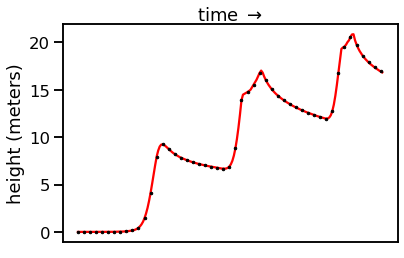

```python
#pull topographic evolution from one spot in the basin
section=[t[454] for t in model_topo]

plt.plot(section,'-',color='r')
plt.plot(np.arange(len(section))[0::4],section[0::4],'.',markersize=5,color='k')

plt.gca().set_xticks([])
plt.gca().set_xlabel(r'time $\rightarrow$')
plt.gca().set_ylabel('height (meters)')
plt.gca().xaxis.set_label_position('top')
```

# How to build the net rock record

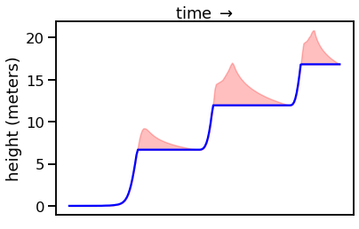

```python
net=np.flipud(section) #flip this stratigraphy upside down to examine youngest to oldest
for i,s in enumerate(net): #count through time slices starting at the youngest
    if i!=len(net)-1: #if we're not at the end
        #look "down section" - was this layer eroded?
        # --> if height had decreased, then yes
        if s<net[i+1]: #s is height of current timeslice, net[i+1] is heigh of previous timeslice
            net[i+1]=s #create new record of net sedimentation
#make stratigraphy younging upwards again
net=np.flipud(net)
plt.plot(net,color='b')
plt.fill_between(np.arange(len(section)),section,net,color='r',alpha=0.25)
plt.gca().set_xticks([])
plt.gca().set_xlabel(r'time $\rightarrow$')
plt.gca().set_ylabel('height (meters)')
plt.gca().xaxis.set_label_position('top')
```

# How to build the net rock record

[figure not shown]

# Coastline position and erosion and hiatus

We will look at a set of model runs to better understand the relationship of the coastline position to **erosion** and **hiatus** (and **time**). First, let's review the controls on coastline position:

- Coastline progrades/regresses/moves seaward when: $\frac{sed}{dt}>\frac{space}{dt}$
- Coastline retrogrades/transgresses/moves landward when: $\frac{sed}{dt}<\frac{space}{dt}$
- Coastline aggrades/stays in the same location landward when: $\frac{sed}{dt}\approx\frac{space}{dt}$

#### Simple sea level cycles: stratigraphic columns

[figure not shown]

#### Simple sea level cycles: time vs topography

[figure not shown]

#### Simple sea level cycles: time vs topography

[figure not shown]

Where do you get erosion? Where is erosion rate maximized? What about non-deposition? *(annotate/draw on your handout)*

#### Simple sea level cycles: time vs topography (erosion)

[figure not shown]

#### Simple sea level cycles: time vs topography (erosion and hiatus)

[figure not shown]

#### Simple sea level cycles: *Wheeler* diagram

[figure not shown]

#### Simple sea level cycles: *Wheeler* diagram

[figure not shown]

Note: not all positive deposition is significant. Discuss where you think the thickest sediments (highest sedimentation rates) are.

#### Simple sea level cycles: stratigraphic profile

[figure not shown]

#### Class example 1: stratigraphic columns

[figure not shown]

#### Class example 1: time vs topography

[figure not shown]

#### Class example 1: time vs topography (erosion)

[figure not shown]

#### Class example 1: time vs topography (erosion and hiatus)

[figure not shown]

#### Class example 1: *Wheeler* diagram

[figure not shown]

#### Class example 1: stratigraphic profile

[figure not shown]

#### Class example 2: stratigraphic columns

[figure not shown]

#### Class example 2: time vs topography

[figure not shown]

#### Class example 2: time vs topography (erosion)

[figure not shown]

#### Class example 2: time vs topography (erosion and hiatus)

[figure not shown]

#### Class example 2: *Wheeler* diagram

[figure not shown]

#### Class example 2: stratigraphic profile

[figure not shown]

#### On/Off sediment supply with constant subsidence: time vs topography

[figure not shown]

#### On/Off sediment supply with constant subsidence: time vs topography

[figure not shown]

#### On/Off sediment supply with constant subsidence: time vs topography (erosion)

[figure not shown]

#### On/Off sediment supply with constant subsidence: time vs topography (erosion and hiatus)

[figure not shown]

#### On/Off sediment supply with constant subsidence: *Wheeler* diagram

[figure not shown]

#### On/Off sediment supply with constant subsidence: stratigraphic profile

[figure not shown]